# Risk Factor Analysis

## Outcome Variable

**Outcome Variable:** whz

## Predictor Variables

**Intervention Variable:** perdiar24

**Adjustment Set:**

unadjusted

## Stratifying Variables

The analysis was stratified on these variable(s):

- agecat
- studyid
- country

## Data Summary

| agecat | studyid | country | perdiar24 | n_cell | n |
| --- | --- | --- | --- | --- | --- |
| Birth | ki0047075b-MAL-ED | BANGLADESH | 0% | 14 | 215 |
| Birth | ki0047075b-MAL-ED | BANGLADESH | (0%, 5%] | 127 | 215 |
| Birth | ki0047075b-MAL-ED | BANGLADESH | >5% | 74 | 215 |
| Birth | ki0047075b-MAL-ED | BRAZIL | 0% | 34 | 62 |
| Birth | ki0047075b-MAL-ED | BRAZIL | (0%, 5%] | 26 | 62 |
| Birth | ki0047075b-MAL-ED | BRAZIL | >5% | 2 | 62 |
| Birth | ki0047075b-MAL-ED | INDIA | 0% | 5 | 45 |
| Birth | ki0047075b-MAL-ED | INDIA | (0%, 5%] | 31 | 45 |
| Birth | ki0047075b-MAL-ED | INDIA | >5% | 9 | 45 |
| Birth | ki0047075b-MAL-ED | NEPAL | 0% | 2 | 26 |
| Birth | ki0047075b-MAL-ED | NEPAL | (0%, 5%] | 19 | 26 |
| Birth | ki0047075b-MAL-ED | NEPAL | >5% | 5 | 26 |
| Birth | ki0047075b-MAL-ED | PERU | 0% | 21 | 228 |
| Birth | ki0047075b-MAL-ED | PERU | (0%, 5%] | 87 | 228 |
| Birth | ki0047075b-MAL-ED | PERU | >5% | 120 | 228 |
| Birth | ki0047075b-MAL-ED | SOUTH AFRICA | 0% | 42 | 112 |
| Birth | ki0047075b-MAL-ED | SOUTH AFRICA | (0%, 5%] | 69 | 112 |
| Birth | ki0047075b-MAL-ED | SOUTH AFRICA | >5% | 1 | 112 |
| Birth | ki0047075b-MAL-ED | TANZANIA, UNITED REPUBLIC OF | 0% | 7 | 115 |
| Birth | ki0047075b-MAL-ED | TANZANIA, UNITED REPUBLIC OF | (0%, 5%] | 77 | 115 |
| Birth | ki0047075b-MAL-ED | TANZANIA, UNITED REPUBLIC OF | >5% | 31 | 115 |
| Birth | ki1000109-EE | PAKISTAN | 0% | 115 | 177 |
| Birth | ki1000109-EE | PAKISTAN | (0%, 5%] | 62 | 177 |
| Birth | ki1000109-EE | PAKISTAN | >5% | 0 | 177 |
| Birth | ki1017093-NIH-Birth | BANGLADESH | 0% | 46 | 572 |
| Birth | ki1017093-NIH-Birth | BANGLADESH | (0%, 5%] | 327 | 572 |
| Birth | ki1017093-NIH-Birth | BANGLADESH | >5% | 199 | 572 |
| Birth | ki1017093b-PROVIDE | BANGLADESH | 0% | 55 | 532 |
| Birth | ki1017093b-PROVIDE | BANGLADESH | (0%, 5%] | 322 | 532 |
| Birth | ki1017093b-PROVIDE | BANGLADESH | >5% | 155 | 532 |

[output cut: 102 more lines]

The following strata were considered:

- agecat: 24 months, studyid: ki0047075b-MAL-ED, country: BANGLADESH
- agecat: 24 months, studyid: ki0047075b-MAL-ED, country: BRAZIL
- agecat: 24 months, studyid: ki0047075b-MAL-ED, country: INDIA
- agecat: 24 months, studyid: ki0047075b-MAL-ED, country: NEPAL
- agecat: 24 months, studyid: ki0047075b-MAL-ED, country: PERU
- agecat: 24 months, studyid: ki0047075b-MAL-ED, country: SOUTH AFRICA
- agecat: 24 months, studyid: ki0047075b-MAL-ED, country: TANZANIA, UNITED REPUBLIC OF
- agecat: 24 months, studyid: ki1000109-EE, country: PAKISTAN
- agecat: 24 months, studyid: ki1017093-NIH-Birth, country: BANGLADESH
- agecat: 24 months, studyid: ki1017093b-PROVIDE, country: BANGLADESH
- agecat: 24 months, studyid: ki1017093c-NIH-Crypto, country: BANGLADESH
- agecat: 24 months, studyid: ki1114097-CMIN, country: BANGLADESH
- agecat: 24 months, studyid: ki1114097-CONTENT, country: PERU
- agecat: 24 months, studyid: kiGH5241-JiVitA-4, country: BANGLADESH
- agecat: 6 months, studyid: ki0047075b-MAL-ED, country: BANGLADESH
- agecat: 6 months, studyid: ki0047075b-MAL-ED, country: BRAZIL
- agecat: 6 months, studyid: ki0047075b-MAL-ED, country: INDIA
- agecat: 6 months, studyid: ki0047075b-MAL-ED, country: NEPAL
- agecat: 6 months, studyid: ki0047075b-MAL-ED, country: PERU
- agecat: 6 months, studyid: ki0047075b-MAL-ED, country: SOUTH AFRICA
- agecat: 6 months, studyid: ki0047075b-MAL-ED, country: TANZANIA, UNITED REPUBLIC OF
- agecat: 6 months, studyid: ki1000109-EE, country: PAKISTAN
- agecat: 6 months, studyid: ki1000304b-SAS-FoodSuppl, country: INDIA
- agecat: 6 months, studyid: ki1017093-NIH-Birth, country: BANGLADESH
- agecat: 6 months, studyid: ki1017093b-PROVIDE, country: BANGLADESH
- agecat: 6 months, studyid: ki1017093c-NIH-Crypto, country: BANGLADESH
- agecat: 6 months, studyid: ki1112895-Guatemala BSC, country: GUATEMALA
- agecat: 6 months, studyid: ki1114097-CMIN, country: BANGLADESH
- agecat: 6 months, studyid: ki1114097-CONTENT, country: PERU
- agecat: 6 months, studyid: kiGH5241-JiVitA-4, country: BANGLADESH
- agecat: Birth, studyid: ki0047075b-MAL-ED, country: BANGLADESH
- agecat: Birth, studyid: ki0047075b-MAL-ED, country: BRAZIL
- agecat: Birth, studyid: ki0047075b-MAL-ED, country: INDIA
- agecat: Birth, studyid: ki0047075b-MAL-ED, country: NEPAL
- agecat: Birth, studyid: ki0047075b-MAL-ED, country: PERU
- agecat: Birth, studyid: ki0047075b-MAL-ED, country: SOUTH AFRICA
- agecat: Birth, studyid: ki0047075b-MAL-ED, country: TANZANIA, UNITED REPUBLIC OF
- agecat: Birth, studyid: ki1000109-EE, country: PAKISTAN
- agecat: Birth, studyid: ki1017093-NIH-Birth, country: BANGLADESH
- agecat: Birth, studyid: ki1017093b-PROVIDE, country: BANGLADESH
- agecat: Birth, studyid: ki1017093c-NIH-Crypto, country: BANGLADESH
- agecat: Birth, studyid: ki1114097-CMIN, country: BANGLADESH
- agecat: Birth, studyid: ki1114097-CONTENT, country: PERU
- agecat: Birth, studyid: kiGH5241-JiVitA-4, country: BANGLADESH

### Dropped Strata

Some strata were dropped due to rare outcomes:

- agecat: Birth, studyid: ki0047075b-MAL-ED, country: BRAZIL
- agecat: Birth, studyid: ki0047075b-MAL-ED, country: NEPAL
- agecat: Birth, studyid: ki0047075b-MAL-ED, country: SOUTH AFRICA
- agecat: Birth, studyid: ki1000109-EE, country: PAKISTAN
- agecat: Birth, studyid: ki1114097-CMIN, country: BANGLADESH
- agecat: Birth, studyid: ki1114097-CONTENT, country: PERU
- agecat: 6 months, studyid: ki0047075b-MAL-ED, country: BRAZIL
- agecat: 6 months, studyid: ki0047075b-MAL-ED, country: INDIA
- agecat: 6 months, studyid: ki0047075b-MAL-ED, country: SOUTH AFRICA
- agecat: 6 months, studyid: ki1000109-EE, country: PAKISTAN
- agecat: 6 months, studyid: ki1114097-CMIN, country: BANGLADESH
- agecat: 24 months, studyid: ki0047075b-MAL-ED, country: BRAZIL
- agecat: 24 months, studyid: ki0047075b-MAL-ED, country: INDIA
- agecat: 24 months, studyid: ki0047075b-MAL-ED, country: PERU
- agecat: 24 months, studyid: ki0047075b-MAL-ED, country: SOUTH AFRICA
- agecat: 24 months, studyid: ki1000109-EE, country: PAKISTAN
- agecat: 24 months, studyid: ki1114097-CMIN, country: BANGLADESH
- agecat: 24 months, studyid: ki1114097-CONTENT, country: PERU

## Methods Detail

We’re interested in the causal parameters $E[Y_a]$ for all values of $a \in \mathcal{A}$. These parameters represent the mean outcome if, possibly contrary to fact, we intervened to set all units to have $A=a$. Under the randomization and positivity assumptions, these are identified by the statistical parameters $\psi_a=E_W[E_{Y|A,W}(Y|A=a,W)]$. In addition, we’re interested in the mean of $Y$, $E[Y]$ under no intervention (the observed mean). We will estimate these parameters by using SuperLearner to fit the relevant likelihood factors – $E_{Y|A,W}(Y|A=a,W)$ and $p(A=a|W)$, and then updating our likelihood fit using a joint TMLE.

For unadjusted analyses ($W=\{\}$), initial likelihoods were estimated using Lrnr_glm to estimate the simple $E(Y|A)$ and Lrnr_mean to estimate $p(A)$. For adjusted analyses, a small library containing Lrnr_glmnet, Lrnr_xgboost, and Lrnr_mean was used.

Having estimated these parameters, we will then use the delta method to estimate relative risks and attributable risks relative to a prespecified baseline level of $A$.

# Results Detail

## Results Plots

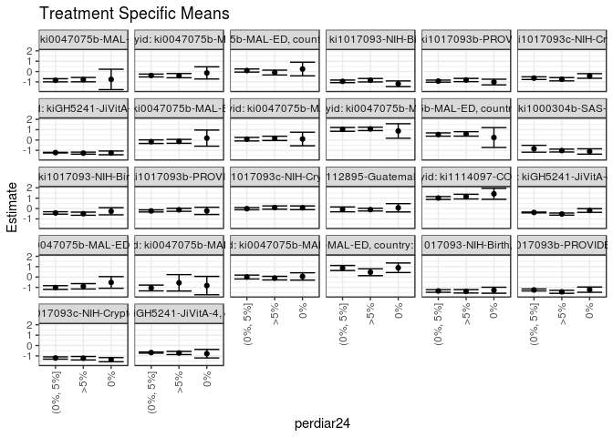

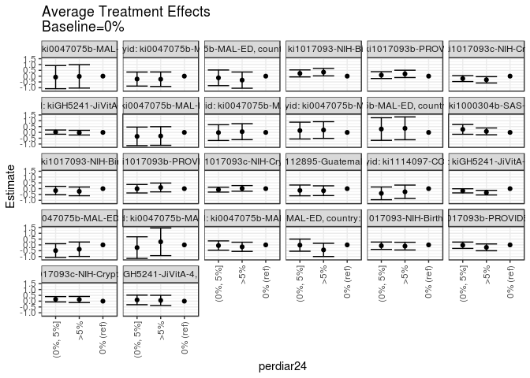

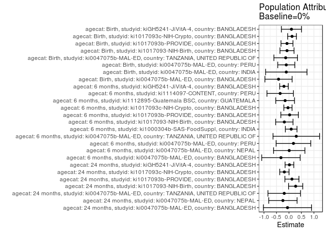

## Results Table

### Parameter: TSM

| agecat | studyid | country | intervention_level | baseline_level | estimate | ci_lower | ci_upper |
| --- | --- | --- | --- | --- | --- | --- | --- |
| Birth | ki0047075b-MAL-ED | BANGLADESH | 0% | NA | -0.5250000 | -1.0876832 | 0.0376832 |
| Birth | ki0047075b-MAL-ED | BANGLADESH | (0%, 5%] | NA | -1.0139764 | -1.1955484 | -0.8324043 |
| Birth | ki0047075b-MAL-ED | BANGLADESH | >5% | NA | -0.8969595 | -1.1559160 | -0.6380030 |
| Birth | ki0047075b-MAL-ED | INDIA | 0% | NA | -0.8260000 | -1.7120476 | 0.0600476 |
| Birth | ki0047075b-MAL-ED | INDIA | (0%, 5%] | NA | -1.0574194 | -1.3366625 | -0.7781762 |
| Birth | ki0047075b-MAL-ED | INDIA | >5% | NA | -0.5611111 | -1.3534381 | 0.2312159 |
| Birth | ki0047075b-MAL-ED | PERU | 0% | NA | 0.0552381 | -0.2982565 | 0.4087327 |
| Birth | ki0047075b-MAL-ED | PERU | (0%, 5%] | NA | -0.0005747 | -0.1877707 | 0.1866213 |
| Birth | ki0047075b-MAL-ED | PERU | >5% | NA | -0.1080833 | -0.2811592 | 0.0649925 |
| Birth | ki0047075b-MAL-ED | TANZANIA, UNITED REPUBLIC OF | 0% | NA | 0.8928571 | 0.4313181 | 1.3543962 |
| Birth | ki0047075b-MAL-ED | TANZANIA, UNITED REPUBLIC OF | (0%, 5%] | NA | 0.8712987 | 0.6273536 | 1.1152438 |
| Birth | ki0047075b-MAL-ED | TANZANIA, UNITED REPUBLIC OF | >5% | NA | 0.4625806 | 0.1300967 | 0.7950646 |
| Birth | ki1017093-NIH-Birth | BANGLADESH | 0% | NA | -1.2752174 | -1.5640572 | -0.9863776 |
| Birth | ki1017093-NIH-Birth | BANGLADESH | (0%, 5%] | NA | -1.3464373 | -1.4730614 | -1.2198132 |
| Birth | ki1017093-NIH-Birth | BANGLADESH | >5% | NA | -1.3804523 | -1.5433461 | -1.2175585 |
| Birth | ki1017093b-PROVIDE | BANGLADESH | 0% | NA | -1.2198182 | -1.4738917 | -0.9657447 |
| Birth | ki1017093b-PROVIDE | BANGLADESH | (0%, 5%] | NA | -1.2484161 | -1.3450944 | -1.1517379 |
| Birth | ki1017093b-PROVIDE | BANGLADESH | >5% | NA | -1.4303226 | -1.5732702 | -1.2873750 |
| Birth | ki1017093c-NIH-Crypto | BANGLADESH | 0% | NA | -1.3677778 | -1.5690583 | -1.1664973 |
| Birth | ki1017093c-NIH-Crypto | BANGLADESH | (0%, 5%] | NA | -1.2052400 | -1.3148134 | -1.0956666 |
| Birth | ki1017093c-NIH-Crypto | BANGLADESH | >5% | NA | -1.2270745 | -1.3939613 | -1.0601877 |
| Birth | kiGH5241-JiVitA-4 | BANGLADESH | 0% | NA | -0.7888525 | -1.2009300 | -0.3767750 |
| Birth | kiGH5241-JiVitA-4 | BANGLADESH | (0%, 5%] | NA | -0.6818077 | -0.7375267 | -0.6260888 |
| Birth | kiGH5241-JiVitA-4 | BANGLADESH | >5% | NA | -0.7220082 | -0.8732817 | -0.5707347 |
| 6 months | ki0047075b-MAL-ED | BANGLADESH | 0% | NA | 0.1833333 | -0.5948965 | 0.9615632 |
| 6 months | ki0047075b-MAL-ED | BANGLADESH | (0%, 5%] | NA | -0.1581455 | -0.3337303 | 0.0174392 |
| 6 months | ki0047075b-MAL-ED | BANGLADESH | >5% | NA | -0.1271326 | -0.3185947 | 0.0643295 |
| 6 months | ki0047075b-MAL-ED | NEPAL | 0% | NA | 0.0995238 | -0.5548966 | 0.7539442 |
| 6 months | ki0047075b-MAL-ED | NEPAL | (0%, 5%] | NA | 0.0831002 | -0.0893967 | 0.2555972 |
| 6 months | ki0047075b-MAL-ED | NEPAL | >5% | NA | 0.1618354 | -0.0448012 | 0.3684721 |
| 6 months | ki0047075b-MAL-ED | PERU | 0% | NA | 0.8728571 | 0.1723061 | 1.5734082 |
| 6 months | ki0047075b-MAL-ED | PERU | (0%, 5%] | NA | 1.0295260 | 0.8447495 | 1.2143025 |
| 6 months | ki0047075b-MAL-ED | PERU | >5% | NA | 1.0771231 | 0.9121893 | 1.2420570 |
| 6 months | ki0047075b-MAL-ED | TANZANIA, UNITED REPUBLIC OF | 0% | NA | 0.2427778 | -0.7161220 | 1.2016775 |
| 6 months | ki0047075b-MAL-ED | TANZANIA, UNITED REPUBLIC OF | (0%, 5%] | NA | 0.5318644 | 0.3720281 | 0.6917007 |
| 6 months | ki0047075b-MAL-ED | TANZANIA, UNITED REPUBLIC OF | >5% | NA | 0.5921585 | 0.3766024 | 0.8077146 |
| 6 months | ki1000304b-SAS-FoodSuppl | INDIA | 0% | NA | -1.1024324 | -1.3607960 | -0.8440689 |
| 6 months | ki1000304b-SAS-FoodSuppl | INDIA | (0%, 5%] | NA | -0.8421739 | -1.1739502 | -0.5103977 |
| 6 months | ki1000304b-SAS-FoodSuppl | INDIA | >5% | NA | -1.0165385 | -1.1569775 | -0.8760994 |
| 6 months | ki1017093-NIH-Birth | BANGLADESH | 0% | NA | -0.2633333 | -0.6076595 | 0.0809928 |
| 6 months | ki1017093-NIH-Birth | BANGLADESH | (0%, 5%] | NA | -0.4280138 | -0.5445518 | -0.3114757 |
| 6 months | ki1017093-NIH-Birth | BANGLADESH | >5% | NA | -0.4984107 | -0.6496061 | -0.3472154 |
| 6 months | ki1017093b-PROVIDE | BANGLADESH | 0% | NA | -0.2258333 | -0.5763596 | 0.1246929 |
| 6 months | ki1017093b-PROVIDE | BANGLADESH | (0%, 5%] | NA | -0.2323203 | -0.3346956 | -0.1299449 |
| 6 months | ki1017093b-PROVIDE | BANGLADESH | >5% | NA | -0.1232514 | -0.2687334 | 0.0222307 |
| 6 months | ki1017093c-NIH-Crypto | BANGLADESH | 0% | NA | 0.0693284 | -0.1122625 | 0.2509192 |
| 6 months | ki1017093c-NIH-Crypto | BANGLADESH | (0%, 5%] | NA | -0.0161010 | -0.1204662 | 0.0882641 |
| 6 months | ki1017093c-NIH-Crypto | BANGLADESH | >5% | NA | 0.0933590 | -0.0657825 | 0.2525004 |
| 6 months | ki1112895-Guatemala BSC | GUATEMALA | 0% | NA | 0.0695977 | -0.3296354 | 0.4688308 |
| 6 months | ki1112895-Guatemala BSC | GUATEMALA | (0%, 5%] | NA | -0.0836190 | -0.3170924 | 0.1498543 |
| 6 months | ki1112895-Guatemala BSC | GUATEMALA | >5% | NA | -0.1064250 | -0.2376031 | 0.0247531 |
| 6 months | ki1114097-CONTENT | PERU | 0% | NA | 1.4197500 | 0.8897030 | 1.9497970 |
| 6 months | ki1114097-CONTENT | PERU | (0%, 5%] | NA | 1.0154953 | 0.8771516 | 1.1538390 |
| 6 months | ki1114097-CONTENT | PERU | >5% | NA | 1.1491642 | 0.9229924 | 1.3753360 |
| 6 months | kiGH5241-JiVitA-4 | BANGLADESH | 0% | NA | -0.1905449 | -0.3677691 | -0.0133206 |
| 6 months | kiGH5241-JiVitA-4 | BANGLADESH | (0%, 5%] | NA | -0.3791091 | -0.4182178 | -0.3400004 |
| 6 months | kiGH5241-JiVitA-4 | BANGLADESH | >5% | NA | -0.5339027 | -0.6361629 | -0.4316425 |
| 24 months | ki0047075b-MAL-ED | BANGLADESH | 0% | NA | -0.7608333 | -1.7455859 | 0.2239193 |
| 24 months | ki0047075b-MAL-ED | BANGLADESH | (0%, 5%] | NA | -0.8440769 | -0.9945327 | -0.6936211 |
| 24 months | ki0047075b-MAL-ED | BANGLADESH | >5% | NA | -0.7815132 | -0.9897171 | -0.5733093 |
| 24 months | ki0047075b-MAL-ED | NEPAL | 0% | NA | -0.1329167 | -0.7214300 | 0.4555967 |
| 24 months | ki0047075b-MAL-ED | NEPAL | (0%, 5%] | NA | -0.3828929 | -0.5211811 | -0.2446046 |
| 24 months | ki0047075b-MAL-ED | NEPAL | >5% | NA | -0.3984211 | -0.6041089 | -0.1927332 |
| 24 months | ki0047075b-MAL-ED | TANZANIA, UNITED REPUBLIC OF | 0% | NA | 0.2433333 | -0.4146176 | 0.9012843 |
| 24 months | ki0047075b-MAL-ED | TANZANIA, UNITED REPUBLIC OF | (0%, 5%] | NA | 0.0989530 | -0.0508664 | 0.2487724 |
| 24 months | ki0047075b-MAL-ED | TANZANIA, UNITED REPUBLIC OF | >5% | NA | -0.0994231 | -0.3337823 | 0.1349362 |
| 24 months | ki1017093-NIH-Birth | BANGLADESH | 0% | NA | -1.1800000 | -1.4547770 | -0.9052230 |
| 24 months | ki1017093-NIH-Birth | BANGLADESH | (0%, 5%] | NA | -0.9456415 | -1.0692081 | -0.8220748 |
| 24 months | ki1017093-NIH-Birth | BANGLADESH | >5% | NA | -0.8370172 | -1.0005302 | -0.6735043 |
| 24 months | ki1017093b-PROVIDE | BANGLADESH | 0% | NA | -1.0127778 | -1.2883897 | -0.7371658 |
| 24 months | ki1017093b-PROVIDE | BANGLADESH | (0%, 5%] | NA | -0.9233081 | -1.0226788 | -0.8239373 |
| 24 months | ki1017093b-PROVIDE | BANGLADESH | >5% | NA | -0.8173851 | -0.9715768 | -0.6631933 |
| 24 months | ki1017093c-NIH-Crypto | BANGLADESH | 0% | NA | -0.4266667 | -0.6484439 | -0.2048894 |
| 24 months | ki1017093c-NIH-Crypto | BANGLADESH | (0%, 5%] | NA | -0.6373551 | -0.7664642 | -0.5082459 |
| 24 months | ki1017093c-NIH-Crypto | BANGLADESH | >5% | NA | -0.7420000 | -0.8997906 | -0.5842094 |
| 24 months | kiGH5241-JiVitA-4 | BANGLADESH | 0% | NA | -1.2420122 | -1.4225780 | -1.0614464 |
| 24 months | kiGH5241-JiVitA-4 | BANGLADESH | (0%, 5%] | NA | -1.2173224 | -1.2503914 | -1.1842534 |
| 24 months | kiGH5241-JiVitA-4 | BANGLADESH | >5% | NA | -1.2650716 | -1.3602515 | -1.1698916 |

### Parameter: E(Y)

| agecat | studyid | country | intervention_level | baseline_level | estimate | ci_lower | ci_upper |
| --- | --- | --- | --- | --- | --- | --- | --- |
| Birth | ki0047075b-MAL-ED | BANGLADESH | NA | NA | -0.9418605 | -1.0869834 | -0.7967375 |
| Birth | ki0047075b-MAL-ED | INDIA | NA | NA | -0.9324444 | -1.2067907 | -0.6580982 |
| Birth | ki0047075b-MAL-ED | PERU | NA | NA | -0.0520175 | -0.1725298 | 0.0684947 |
| Birth | ki0047075b-MAL-ED | TANZANIA, UNITED REPUBLIC OF | NA | NA | 0.7624348 | 0.5710709 | 0.9537986 |
| Birth | ki1017093-NIH-Birth | BANGLADESH | NA | NA | -1.3525437 | -1.4473932 | -1.2576942 |
| Birth | ki1017093b-PROVIDE | BANGLADESH | NA | NA | -1.2984586 | -1.3752758 | -1.2216415 |
| Birth | ki1017093c-NIH-Crypto | BANGLADESH | NA | NA | -1.2441513 | -1.3281130 | -1.1601897 |
| Birth | kiGH5241-JiVitA-4 | BANGLADESH | NA | NA | -0.6886269 | -0.7410452 | -0.6362086 |
| 6 months | ki0047075b-MAL-ED | BANGLADESH | NA | NA | -0.1376763 | -0.2664642 | -0.0088885 |
| 6 months | ki0047075b-MAL-ED | NEPAL | NA | NA | 0.1104308 | -0.0208643 | 0.2417259 |
| 6 months | ki0047075b-MAL-ED | PERU | NA | NA | 1.0528816 | 0.9313005 | 1.1744626 |
| 6 months | ki0047075b-MAL-ED | TANZANIA, UNITED REPUBLIC OF | NA | NA | 0.5362213 | 0.4049390 | 0.6675036 |
| 6 months | ki1000304b-SAS-FoodSuppl | INDIA | NA | NA | -1.0121579 | -1.1280429 | -0.8962729 |
| 6 months | ki1017093-NIH-Birth | BANGLADESH | NA | NA | -0.4474038 | -0.5378167 | -0.3569909 |
| 6 months | ki1017093b-PROVIDE | BANGLADESH | NA | NA | -0.1990907 | -0.2817968 | -0.1163845 |
| 6 months | ki1017093c-NIH-Crypto | BANGLADESH | NA | NA | 0.0297622 | -0.0491685 | 0.1086930 |
| 6 months | ki1112895-Guatemala BSC | GUATEMALA | NA | NA | -0.0840134 | -0.1945572 | 0.0265305 |
| 6 months | ki1114097-CONTENT | PERU | NA | NA | 1.0684318 | 0.9515274 | 1.1853362 |
| 6 months | kiGH5241-JiVitA-4 | BANGLADESH | NA | NA | -0.3898055 | -0.4270507 | -0.3525603 |
| 24 months | ki0047075b-MAL-ED | BANGLADESH | NA | NA | -0.8192925 | -0.9412667 | -0.6973182 |
| 24 months | ki0047075b-MAL-ED | NEPAL | NA | NA | -0.3749123 | -0.4886073 | -0.2612173 |
| 24 months | ki0047075b-MAL-ED | TANZANIA, UNITED REPUBLIC OF | NA | NA | 0.0547975 | -0.0703378 | 0.1799328 |
| 24 months | ki1017093-NIH-Birth | BANGLADESH | NA | NA | -0.9115790 | -1.0095022 | -0.8136559 |
| 24 months | ki1017093b-PROVIDE | BANGLADESH | NA | NA | -0.8928670 | -0.9755153 | -0.8102187 |
| 24 months | ki1017093c-NIH-Crypto | BANGLADESH | NA | NA | -0.6103502 | -0.7050157 | -0.5156847 |
| 24 months | kiGH5241-JiVitA-4 | BANGLADESH | NA | NA | -1.2231088 | -1.2549632 | -1.1912543 |

### Parameter: ATE

| agecat | studyid | country | intervention_level | baseline_level | estimate | ci_lower | ci_upper |
| --- | --- | --- | --- | --- | --- | --- | --- |
| Birth | ki0047075b-MAL-ED | BANGLADESH | 0% | 0% | 0.0000000 | 0.0000000 | 0.0000000 |
| Birth | ki0047075b-MAL-ED | BANGLADESH | (0%, 5%] | 0% | -0.4889764 | -1.0802300 | 0.1022772 |
| Birth | ki0047075b-MAL-ED | BANGLADESH | >5% | 0% | -0.3719595 | -0.9913711 | 0.2474522 |
| Birth | ki0047075b-MAL-ED | INDIA | 0% | 0% | 0.0000000 | 0.0000000 | 0.0000000 |
| Birth | ki0047075b-MAL-ED | INDIA | (0%, 5%] | 0% | -0.2314194 | -1.1604280 | 0.6975893 |
| Birth | ki0047075b-MAL-ED | INDIA | >5% | 0% | 0.2648889 | -0.9237500 | 1.4535278 |
| Birth | ki0047075b-MAL-ED | PERU | 0% | 0% | 0.0000000 | 0.0000000 | 0.0000000 |
| Birth | ki0047075b-MAL-ED | PERU | (0%, 5%] | 0% | -0.0558128 | -0.4558137 | 0.3441881 |
| Birth | ki0047075b-MAL-ED | PERU | >5% | 0% | -0.1633214 | -0.5569122 | 0.2302693 |
| Birth | ki0047075b-MAL-ED | TANZANIA, UNITED REPUBLIC OF | 0% | 0% | 0.0000000 | 0.0000000 | 0.0000000 |
| Birth | ki0047075b-MAL-ED | TANZANIA, UNITED REPUBLIC OF | (0%, 5%] | 0% | -0.0215584 | -0.5436001 | 0.5004833 |
| Birth | ki0047075b-MAL-ED | TANZANIA, UNITED REPUBLIC OF | >5% | 0% | -0.4302765 | -0.9991033 | 0.1385503 |
| Birth | ki1017093-NIH-Birth | BANGLADESH | 0% | 0% | 0.0000000 | 0.0000000 | 0.0000000 |
| Birth | ki1017093-NIH-Birth | BANGLADESH | (0%, 5%] | 0% | -0.0712199 | -0.3865960 | 0.2441562 |
| Birth | ki1017093-NIH-Birth | BANGLADESH | >5% | 0% | -0.1052349 | -0.4368413 | 0.2263716 |
| Birth | ki1017093b-PROVIDE | BANGLADESH | 0% | 0% | 0.0000000 | 0.0000000 | 0.0000000 |
| Birth | ki1017093b-PROVIDE | BANGLADESH | (0%, 5%] | 0% | -0.0285980 | -0.3004435 | 0.2432476 |
| Birth | ki1017093b-PROVIDE | BANGLADESH | >5% | 0% | -0.2105044 | -0.5020303 | 0.0810215 |
| Birth | ki1017093c-NIH-Crypto | BANGLADESH | 0% | 0% | 0.0000000 | 0.0000000 | 0.0000000 |
| Birth | ki1017093c-NIH-Crypto | BANGLADESH | (0%, 5%] | 0% | 0.1625378 | -0.0666350 | 0.3917105 |
| Birth | ki1017093c-NIH-Crypto | BANGLADESH | >5% | 0% | 0.1407033 | -0.1207638 | 0.4021704 |
| Birth | kiGH5241-JiVitA-4 | BANGLADESH | 0% | 0% | 0.0000000 | 0.0000000 | 0.0000000 |
| Birth | kiGH5241-JiVitA-4 | BANGLADESH | (0%, 5%] | 0% | 0.1070447 | -0.3063399 | 0.5204293 |
| Birth | kiGH5241-JiVitA-4 | BANGLADESH | >5% | 0% | 0.0668443 | -0.3708998 | 0.5045884 |
| 6 months | ki0047075b-MAL-ED | BANGLADESH | 0% | 0% | 0.0000000 | 0.0000000 | 0.0000000 |
| 6 months | ki0047075b-MAL-ED | BANGLADESH | (0%, 5%] | 0% | -0.3414789 | -1.1392706 | 0.4563129 |
| 6 months | ki0047075b-MAL-ED | BANGLADESH | >5% | 0% | -0.3104659 | -1.1119018 | 0.4909699 |
| 6 months | ki0047075b-MAL-ED | NEPAL | 0% | 0% | 0.0000000 | 0.0000000 | 0.0000000 |
| 6 months | ki0047075b-MAL-ED | NEPAL | (0%, 5%] | 0% | -0.0164236 | -0.6931963 | 0.6603491 |
| 6 months | ki0047075b-MAL-ED | NEPAL | >5% | 0% | 0.0623116 | -0.6239571 | 0.7485804 |
| 6 months | ki0047075b-MAL-ED | PERU | 0% | 0% | 0.0000000 | 0.0000000 | 0.0000000 |
| 6 months | ki0047075b-MAL-ED | PERU | (0%, 5%] | 0% | 0.1566689 | -0.5678407 | 0.8811784 |
| 6 months | ki0047075b-MAL-ED | PERU | >5% | 0% | 0.2042660 | -0.5154387 | 0.9239707 |
| 6 months | ki0047075b-MAL-ED | TANZANIA, UNITED REPUBLIC OF | 0% | 0% | 0.0000000 | 0.0000000 | 0.0000000 |
| 6 months | ki0047075b-MAL-ED | TANZANIA, UNITED REPUBLIC OF | (0%, 5%] | 0% | 0.2890866 | -0.6830432 | 1.2612164 |
| 6 months | ki0047075b-MAL-ED | TANZANIA, UNITED REPUBLIC OF | >5% | 0% | 0.3493807 | -0.6334485 | 1.3322099 |
| 6 months | ki1000304b-SAS-FoodSuppl | INDIA | 0% | 0% | 0.0000000 | 0.0000000 | 0.0000000 |
| 6 months | ki1000304b-SAS-FoodSuppl | INDIA | (0%, 5%] | 0% | 0.2602585 | -0.1602497 | 0.6807668 |
| 6 months | ki1000304b-SAS-FoodSuppl | INDIA | >5% | 0% | 0.0858940 | -0.2081721 | 0.3799600 |
| 6 months | ki1017093-NIH-Birth | BANGLADESH | 0% | 0% | 0.0000000 | 0.0000000 | 0.0000000 |
| 6 months | ki1017093-NIH-Birth | BANGLADESH | (0%, 5%] | 0% | -0.1646804 | -0.5281933 | 0.1988324 |
| 6 months | ki1017093-NIH-Birth | BANGLADESH | >5% | 0% | -0.2350774 | -0.6111366 | 0.1409818 |
| 6 months | ki1017093b-PROVIDE | BANGLADESH | 0% | 0% | 0.0000000 | 0.0000000 | 0.0000000 |
| 6 months | ki1017093b-PROVIDE | BANGLADESH | (0%, 5%] | 0% | -0.0064869 | -0.3716572 | 0.3586834 |
| 6 months | ki1017093b-PROVIDE | BANGLADESH | >5% | 0% | 0.1025820 | -0.2769357 | 0.4820996 |
| 6 months | ki1017093c-NIH-Crypto | BANGLADESH | 0% | 0% | 0.0000000 | 0.0000000 | 0.0000000 |
| 6 months | ki1017093c-NIH-Crypto | BANGLADESH | (0%, 5%] | 0% | -0.0854294 | -0.2948747 | 0.1240159 |
| 6 months | ki1017093c-NIH-Crypto | BANGLADESH | >5% | 0% | 0.0240306 | -0.2174259 | 0.2654871 |
| 6 months | ki1112895-Guatemala BSC | GUATEMALA | 0% | 0% | 0.0000000 | 0.0000000 | 0.0000000 |
| 6 months | ki1112895-Guatemala BSC | GUATEMALA | (0%, 5%] | 0% | -0.1532167 | -0.6157066 | 0.3092731 |
| 6 months | ki1112895-Guatemala BSC | GUATEMALA | >5% | 0% | -0.1760227 | -0.5962545 | 0.2442091 |
| 6 months | ki1114097-CONTENT | PERU | 0% | 0% | 0.0000000 | 0.0000000 | 0.0000000 |
| 6 months | ki1114097-CONTENT | PERU | (0%, 5%] | 0% | -0.4042547 | -0.9520583 | 0.1435489 |
| 6 months | ki1114097-CONTENT | PERU | >5% | 0% | -0.2705858 | -0.8468700 | 0.3056984 |
| 6 months | kiGH5241-JiVitA-4 | BANGLADESH | 0% | 0% | 0.0000000 | 0.0000000 | 0.0000000 |
| 6 months | kiGH5241-JiVitA-4 | BANGLADESH | (0%, 5%] | 0% | -0.1885642 | -0.3667348 | -0.0103936 |
| 6 months | kiGH5241-JiVitA-4 | BANGLADESH | >5% | 0% | -0.3433578 | -0.5425158 | -0.1441998 |
| 24 months | ki0047075b-MAL-ED | BANGLADESH | 0% | 0% | 0.0000000 | 0.0000000 | 0.0000000 |
| 24 months | ki0047075b-MAL-ED | BANGLADESH | (0%, 5%] | 0% | -0.0832436 | -1.0794236 | 0.9129364 |
| 24 months | ki0047075b-MAL-ED | BANGLADESH | >5% | 0% | -0.0206798 | -1.0272018 | 0.9858422 |
| 24 months | ki0047075b-MAL-ED | NEPAL | 0% | 0% | 0.0000000 | 0.0000000 | 0.0000000 |
| 24 months | ki0047075b-MAL-ED | NEPAL | (0%, 5%] | 0% | -0.2499762 | -0.8545187 | 0.3545663 |
| 24 months | ki0047075b-MAL-ED | NEPAL | >5% | 0% | -0.2655044 | -0.8889268 | 0.3579180 |
| 24 months | ki0047075b-MAL-ED | TANZANIA, UNITED REPUBLIC OF | 0% | 0% | 0.0000000 | 0.0000000 | 0.0000000 |
| 24 months | ki0047075b-MAL-ED | TANZANIA, UNITED REPUBLIC OF | (0%, 5%] | 0% | -0.1443803 | -0.8191731 | 0.5304124 |
| 24 months | ki0047075b-MAL-ED | TANZANIA, UNITED REPUBLIC OF | >5% | 0% | -0.3427564 | -1.0412002 | 0.3556873 |
| 24 months | ki1017093-NIH-Birth | BANGLADESH | 0% | 0% | 0.0000000 | 0.0000000 | 0.0000000 |
| 24 months | ki1017093-NIH-Birth | BANGLADESH | (0%, 5%] | 0% | 0.2343585 | -0.0669240 | 0.5356410 |
| 24 months | ki1017093-NIH-Birth | BANGLADESH | >5% | 0% | 0.3429828 | 0.0232346 | 0.6627310 |
| 24 months | ki1017093b-PROVIDE | BANGLADESH | 0% | 0% | 0.0000000 | 0.0000000 | 0.0000000 |
| 24 months | ki1017093b-PROVIDE | BANGLADESH | (0%, 5%] | 0% | 0.0894697 | -0.2035090 | 0.3824484 |
| 24 months | ki1017093b-PROVIDE | BANGLADESH | >5% | 0% | 0.1953927 | -0.1204190 | 0.5112044 |
| 24 months | ki1017093c-NIH-Crypto | BANGLADESH | 0% | 0% | 0.0000000 | 0.0000000 | 0.0000000 |
| 24 months | ki1017093c-NIH-Crypto | BANGLADESH | (0%, 5%] | 0% | -0.2106884 | -0.4673094 | 0.0459326 |
| 24 months | ki1017093c-NIH-Crypto | BANGLADESH | >5% | 0% | -0.3153333 | -0.5875153 | -0.0431514 |
| 24 months | kiGH5241-JiVitA-4 | BANGLADESH | 0% | 0% | 0.0000000 | 0.0000000 | 0.0000000 |
| 24 months | kiGH5241-JiVitA-4 | BANGLADESH | (0%, 5%] | 0% | 0.0246898 | -0.1562765 | 0.2056561 |
| 24 months | kiGH5241-JiVitA-4 | BANGLADESH | >5% | 0% | -0.0230594 | -0.2244678 | 0.1783490 |

### Parameter: PAR

| agecat | studyid | country | intervention_level | baseline_level | estimate | ci_lower | ci_upper |
| --- | --- | --- | --- | --- | --- | --- | --- |
| Birth | ki0047075b-MAL-ED | BANGLADESH | 0% | NA | -0.4168605 | -0.9613233 | 0.1276024 |
| Birth | ki0047075b-MAL-ED | INDIA | 0% | NA | -0.1064444 | -0.9346255 | 0.7217366 |
| Birth | ki0047075b-MAL-ED | PERU | 0% | NA | -0.1072556 | -0.4485223 | 0.2340110 |
| Birth | ki0047075b-MAL-ED | TANZANIA, UNITED REPUBLIC OF | 0% | NA | -0.1304224 | -0.6033978 | 0.3425531 |
| Birth | ki1017093-NIH-Birth | BANGLADESH | 0% | NA | -0.0773263 | -0.3584069 | 0.2037543 |
| Birth | ki1017093b-PROVIDE | BANGLADESH | 0% | NA | -0.0786405 | -0.3176106 | 0.1603296 |
| Birth | ki1017093c-NIH-Crypto | BANGLADESH | 0% | NA | 0.1236264 | -0.0526117 | 0.2998646 |
| Birth | kiGH5241-JiVitA-4 | BANGLADESH | 0% | NA | 0.1002256 | -0.3023844 | 0.5028355 |
| 6 months | ki0047075b-MAL-ED | BANGLADESH | 0% | NA | -0.3210097 | -1.0903899 | 0.4483705 |
| 6 months | ki0047075b-MAL-ED | NEPAL | 0% | NA | 0.0109070 | -0.6173392 | 0.6391532 |
| 6 months | ki0047075b-MAL-ED | PERU | 0% | NA | 0.1800244 | -0.5130743 | 0.8731232 |
| 6 months | ki0047075b-MAL-ED | TANZANIA, UNITED REPUBLIC OF | 0% | NA | 0.2934435 | -0.6391424 | 1.2260295 |
| 6 months | ki1000304b-SAS-FoodSuppl | INDIA | 0% | NA | 0.0902745 | -0.1424979 | 0.3230470 |
| 6 months | ki1017093-NIH-Birth | BANGLADESH | 0% | NA | -0.1840705 | -0.5306415 | 0.1625006 |
| 6 months | ki1017093b-PROVIDE | BANGLADESH | 0% | NA | 0.0267427 | -0.3247762 | 0.3782615 |
| 6 months | ki1017093c-NIH-Crypto | BANGLADESH | 0% | NA | -0.0395661 | -0.2034116 | 0.1242794 |
| 6 months | ki1112895-Guatemala BSC | GUATEMALA | 0% | NA | -0.1536111 | -0.5286966 | 0.2214744 |
| 6 months | ki1114097-CONTENT | PERU | 0% | NA | -0.3513182 | -0.8794617 | 0.1768252 |
| 6 months | kiGH5241-JiVitA-4 | BANGLADESH | 0% | NA | -0.1992606 | -0.3711115 | -0.0274097 |
| 24 months | ki0047075b-MAL-ED | BANGLADESH | 0% | NA | -0.0584591 | -1.0226814 | 0.9057631 |
| 24 months | ki0047075b-MAL-ED | NEPAL | 0% | NA | -0.2419956 | -0.8101653 | 0.3261741 |
| 24 months | ki0047075b-MAL-ED | TANZANIA, UNITED REPUBLIC OF | 0% | NA | -0.1885358 | -0.8399063 | 0.4628347 |
| 24 months | ki1017093-NIH-Birth | BANGLADESH | 0% | NA | 0.2684210 | -0.0167391 | 0.5535810 |
| 24 months | ki1017093b-PROVIDE | BANGLADESH | 0% | NA | 0.1199108 | -0.1611490 | 0.4009705 |
| 24 months | ki1017093c-NIH-Crypto | BANGLADESH | 0% | NA | -0.1836835 | -0.3697124 | 0.0023453 |
| 24 months | kiGH5241-JiVitA-4 | BANGLADESH | 0% | NA | 0.0189034 | -0.1555041 | 0.1933110 |